# Model ARIMA

Author

Abdullah’ Ammar Rabbaniyyin_M0401241066

Published

October 1, 2026

# 1 Library

```r
library(ggplot2)
library(tsibble)
library(tseries)
library(MASS)
library(forecast)
library(TSA)
library(TTR)
library(aTSA)
library(graphics)
library(dplyr)
```

# 2 Data

```r
data <- read.csv("D:\\Mine\\Kuliah Journey\\Semester 5\\MPDW\\mpdw_066\\Data\\BMRI.JK_historis.csv")
head(data)
```

```
                       Date     Open     High      Low    Close    Volume
1 2021-08-25 00:00:00+07:00 2076.208 2111.547 2067.373 2102.712  60726800
2 2021-08-26 00:00:00+07:00 2067.373 2093.878 2058.538 2058.538  55050200
3 2021-08-27 00:00:00+07:00 2058.538 2076.208 2040.868 2049.703  35765000
4 2021-08-30 00:00:00+07:00 2067.373 2102.712 2058.538 2102.712  65062000
5 2021-08-31 00:00:00+07:00 2120.382 2155.722 2102.712 2155.722 135700400
6 2021-09-01 00:00:00+07:00 2155.722 2155.722 2120.382 2120.382  70082000
  Dividends Stock.Splits
1         0            0
2         0            0
3         0            0
4         0            0
5         0            0
6         0            0
```

# 3 Eksplorasi Data

```r
glimpse(data)
```

```
Rows: 1,203
Columns: 8
$ Date         <chr> "2021-08-25 00:00:00+07:00", "2021-08-26 00:00:00+07:00",…
$ Open         <dbl> 2076.208, 2067.373, 2058.538, 2067.373, 2120.382, 2155.72…
$ High         <dbl> 2111.547, 2093.878, 2076.208, 2102.712, 2155.722, 2155.72…
$ Low          <dbl> 2067.373, 2058.538, 2040.868, 2058.538, 2102.712, 2120.38…
$ Close        <dbl> 2102.712, 2058.538, 2049.703, 2102.712, 2155.722, 2120.38…
$ Volume       <int> 60726800, 55050200, 35765000, 65062000, 135700400, 700820…
$ Dividends    <dbl> 0, 0, 0, 0, 0, 0, 0, 0, 0, 0, 0, 0, 0, 0, 0, 0, 0, 0, 0, …
$ Stock.Splits <dbl> 0, 0, 0, 0, 0, 0, 0, 0, 0, 0, 0, 0, 0, 0, 0, 0, 0, 0, 0, …
```

Dataset terdiri dari 8 variabel. Dalam pemodelan ARIMA, variabel yang digunakan adalah `Close`, yaitu harga penutupan saham BMRI setiap hari. Variabel lainnya tidak digunakan karena ARIMA yang digunakan merupakan model univariat, sehingga hanya menganalisis satu deret waktu.

```r
colSums(is.na(data))
```

```
        Date         Open         High          Low        Close       Volume
           0            0            0            0            0            0
   Dividends Stock.Splits
           0            0
```

Tidak ada missing value pada data

```r
data.ts <- ts(data$Close)
summary(data.ts)
```

```
   Min. 1st Qu.  Median    Mean 3rd Qu.    Max.
   2050    3642    4200    4112    4662    6095
```

```r
sd(data.ts)
```

```
[1] 929.7283
```

Data berada pada rentang 2050 dan 6095 dengan simpangan baku yang besar yang membuat data sangat bervariasi.

## 3.1 Plot Data

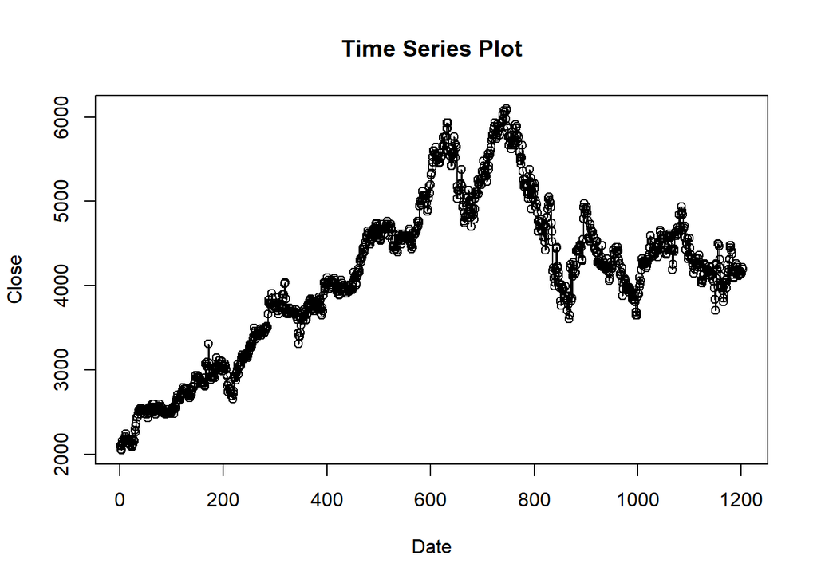

```r
ts.plot(data.ts, xlab="Date", ylab="Close",
        main = "Time Series Plot")
points(data.ts)
```

Pola ini menunjukkan bahwa data belum stasioner dalam rataan, karena terdapat perubahan level/tren yang cukup jelas dari waktu ke waktu. Oleh karena itu, perlu dilakukan uji stasioneritas lebih lanjut menggunakan ACF dan ADF, dan jika belum stasioner maka dapat dilakukan differencing.

# 4 Split

```r
n <- nrow(data)

n_train <- floor(0.85 * n)

# bagi data
training <- data[1:n_train, ]
testing  <- data[(n_train+1):n, ]

# ubah ke time series
train.ts <- ts(training$Close)
test.ts  <- ts(testing$Close)
```

Data dibagi menjadi data train dan test (85:15)

## 4.1 Plot Data Train

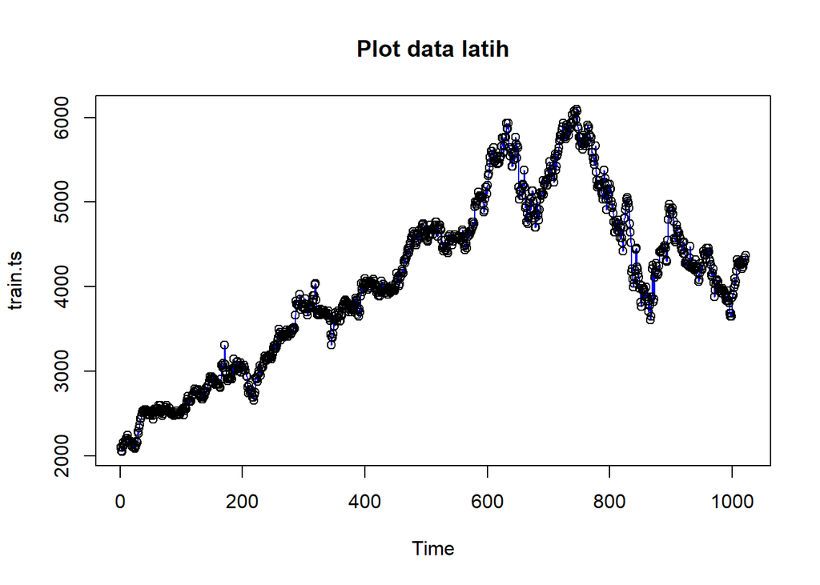

```r
plot(train.ts, col="blue",main="Plot data latih")
points(train.ts)
```

## 4.2 Plot Data Test

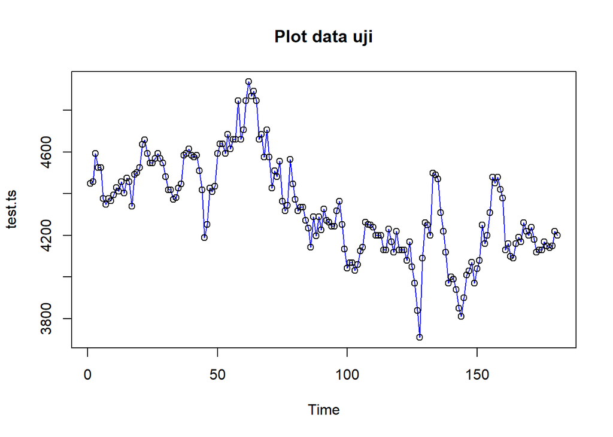

```r
plot(test.ts, col="blue",main="Plot data uji")
points(test.ts)
```

```r
training <- training %>%
  mutate(Date = as.Date(Date))

testing <- testing %>%
  mutate(Date = as.Date(Date))

training$Date <- as.Date(training$Date)
testing$Date <- as.Date(testing$Date)
```

## 4.3 Plot Split

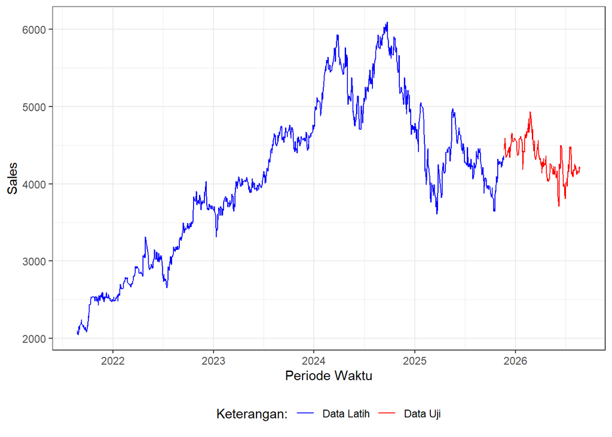

```r
ggplot() +
  geom_line(data = training, aes(x = Date, y = Close, col = "Data Latih")) +
  geom_line(data = testing, aes(x = Date, y = Close, col = "Data Uji")) +
  labs(x = "Periode Waktu", y = "Sales", color = "Legend") +
   scale_colour_manual(name="Keterangan:", breaks = c("Data Latih", "Data Uji"),
                      values = c("blue", "red")) +
  theme_bw() + theme(legend.position = "bottom",
                     plot.caption = element_text(hjust=0.5, size=12))
```

# 5 Kestasioneran

## 5.1 Uji ACF

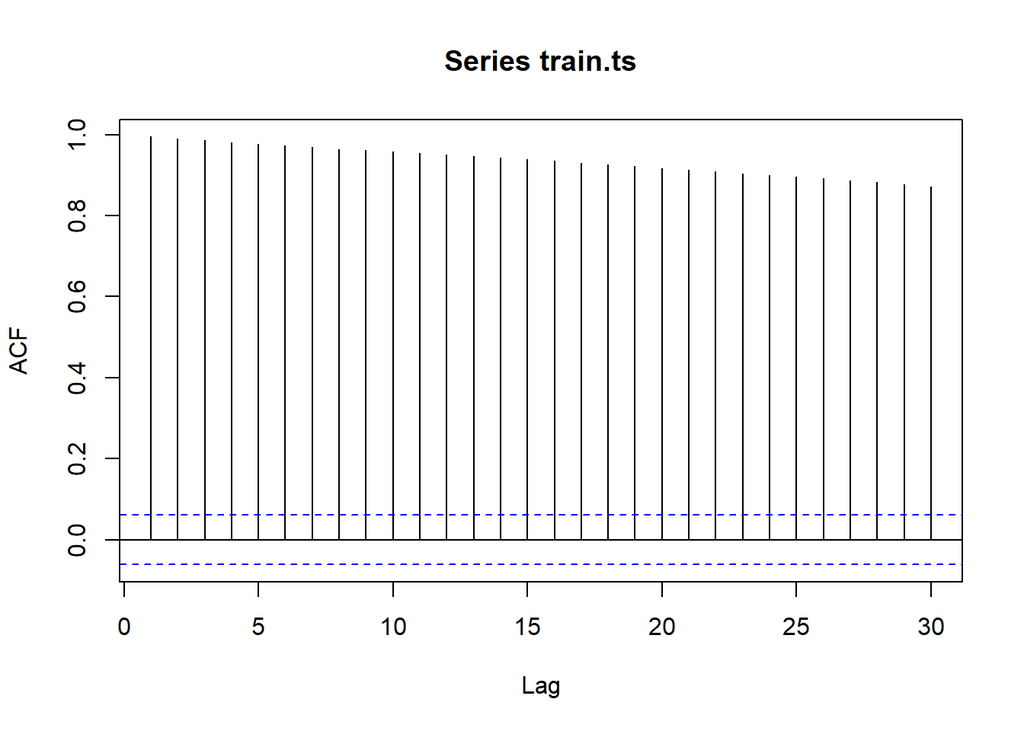

```r
acf(train.ts)
```

Berdasarkan plot ACF data training, hampir seluruh nilai ACF dari lag 1 hingga 30 berada sangat tinggi dan berada di luar batas confidence interval. ACF juga menurun sangat lambat. Hal ini menunjukkan adanya autokorelasi yang kuat dan mengindikasikan bahwa data Close belum stasioner dalam rataan. Oleh karena itu, data perlu dilakukan differencing sebelum menentukan model ARIMA.

## 5.2 Uji ADF

$$\begin{aligned}
H_0 &: \text{Data memiliki unit root (tidak stasioner)}\\
H_1 &: \text{Data tidak memiliki unit root (stasioner)}
\end{aligned}$$

```r
tseries::adf.test(train.ts)
```

```
    Augmented Dickey-Fuller Test

data:  train.ts
Dickey-Fuller = -1.1839, Lag order = 10, p-value = 0.9091
alternative hypothesis: stationary
```

Karena $p-value = 0.9091 > 0.05$, maka Tak Tolak $H_0$. Jadi, data Close pada data training belum stasioner dalam rataan. Oleh karena itu, perlu dilakukan differencing, kemungkinan dimulai dengan differencing orde 1.

## 5.3 Boxcox

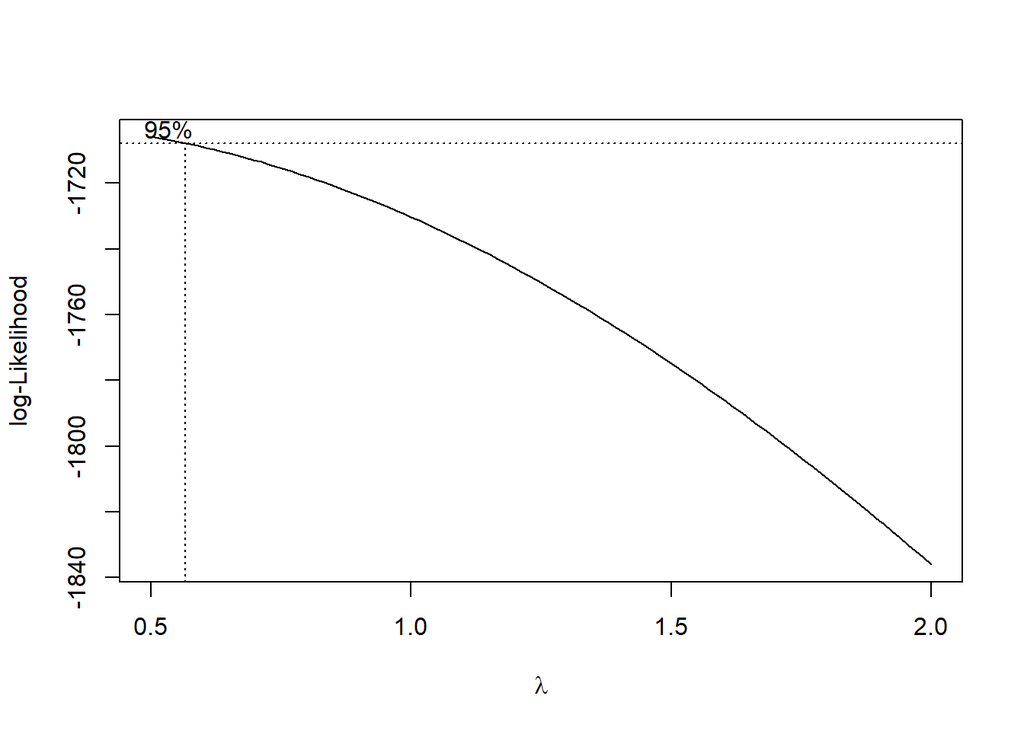

```r
index <- seq(1:1022)

# Box-Cox
bc <- boxcox(train.ts ~ index, lambda = seq(0.5, 2, by = 0.1))
```

```r
lambda_opt <- bc$x[which.max(bc$y)]
lambda_opt
```

```
[1] 0.5
```

```r
# Selang kepercayaan 95% untuk lambda
ci_lambda <- bc$x[bc$y > max(bc$y) - 0.5 * qchisq(0.95, df = 1)]

# Batas bawah dan batas atas
ci_lower <- min(ci_lambda)
ci_upper <- max(ci_lambda)

c(Batas_Bawah = ci_lower, Batas_Atas = ci_upper)
```

```
Batas_Bawah  Batas_Atas
  0.5000000   0.5606061
```

Berdasarkan metode Box-cox, didapatkan bahwa lambda yang optimum adalah 0,5 dengan batas bawah 0,5 dan batas atas 0,56 (Tidak mengandung angka 1). Tidak stasioner dalam ragam.

# 6 Penanganan Ketidakstasioneran

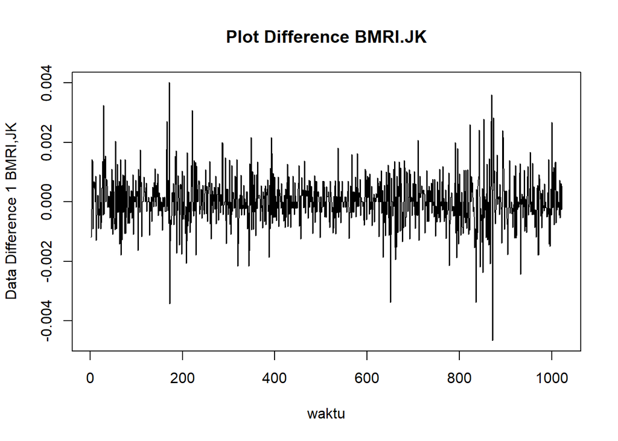

```r
lambda <- BoxCox.lambda(train.ts)

# Transformasi Box-Cox
train.bc <- BoxCox(train.ts, lambda = lambda)

# Differencing
train.diff <-diff(train.bc,differences = 1)

# Plot hasil differencing
plot.ts(train.diff, lty=1, xlab="waktu", ylab="Data Difference 1 BMRI,JK", main="Plot Difference BMRI.JK")
```

Plot first differencing BMRI menunjukkan bahwa data hasil differencing sudah berfluktuasi di sekitar nilai 0 dan tidak menunjukkan tren naik atau turun yang jelas. Namun, terlihat beberapa lonjakan ekstrem pada periode tertentu, terutama setelah sekitar pengamatan ke-600. Ini menunjukkan adanya volatilitas yang cukup tinggi. Secara visual, hasil differencing lebih mendekati stasioner dalam rataan, tetapi tetap perlu dikonfirmasi lebih lanjut.

## 6.1 Uji ACF

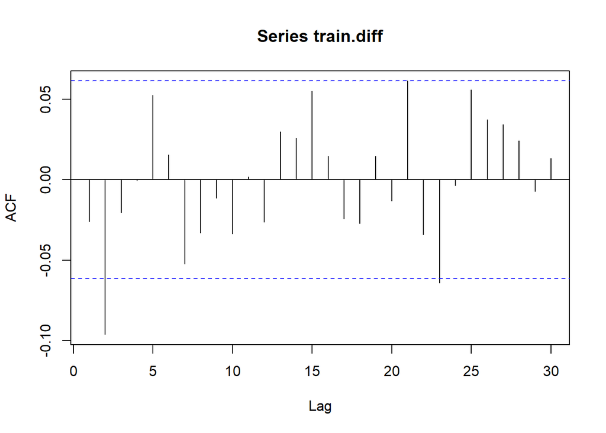

```r
acf(train.diff)
```

Berdasarkan plot ACF setelah differencing, sebagian besar nilai ACF berada dalam batas confidence interval 95%. Hal ini menunjukkan autokorelasi telah berkurang secara signifikan sehingga data hasil differencing sudah lebih mendekati stasioner dalam rataan.

## 6.2 Uji ADF

$$\begin{aligned}
H_0 &: \text{Data memiliki unit root (tidak stasioner)}\\
H_1 &: \text{Data tidak memiliki unit root (stasioner)}
\end{aligned}$$

```r
tseries::adf.test(train.diff)
```

```
    Augmented Dickey-Fuller Test

data:  train.diff
Dickey-Fuller = -10.927, Lag order = 10, p-value = 0.01
alternative hypothesis: stationary
```

Karena $p-value = 0,01 < 0,05$, maka Tolak $H_0$. Artinya, data train.diff sudah stasioner dalam rataan. Jadi, proses differencing orde 1 berhasil mengatasi ketidakstasioneran dalam rataan, sehingga diperoleh $d=1$.

## 6.3 Boxcox

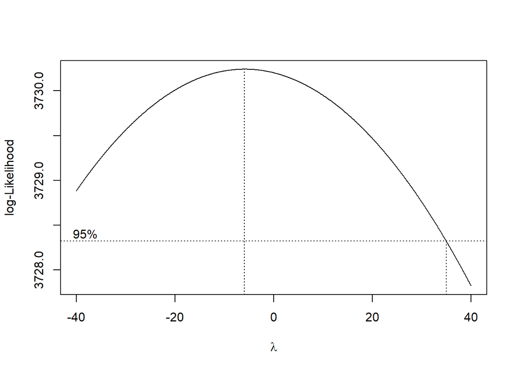

```r
library(MASS)
# 1. Sesuaikan panjang index karena differencing menghilangkan 1 observasi awal
index_diff <- seq(1:length(train.diff))

# 2. Cek apakah ada nilai negatif/nol. Jika ada, tambahkan konstanta (c)
# agar nilai minimum data menjadi > 0 (misalnya menjadi 1)
min_val <- min(train.diff)

if (min_val <= 0) {
  c <- abs(min_val) + 1
  train.diff_shifted <- train.diff + c
} else {
  train.diff_shifted <- train.diff
}

# 3. Plot Box-Cox pada data yang sudah di-shift
bc_diff <- boxcox(train.diff_shifted ~ index_diff, lambda = seq(-40, 40, by = 0.1))
```

```r
# Selang kepercayaan 95% untuk lambda
ci_lambda_diff <- bc_diff$x[
  bc_diff$y > max(bc_diff$y) -
    0.5 * qchisq(0.95, df = 1)
]

ci_lower <- min(ci_lambda_diff)
ci_upper <- max(ci_lambda_diff)

c(Batas_Bawah = ci_lower,
  Batas_Atas = ci_upper)
```

```
Batas_Bawah  Batas_Atas
      -40.0        34.9
```

Karena interval kepercayaan λ sebesar (-40 ; 34,9) mengandung angka 1, jadi data sudah stasioner dalam ragam.

# 7 Identifikasi Model

## 7.1 Plot ACF

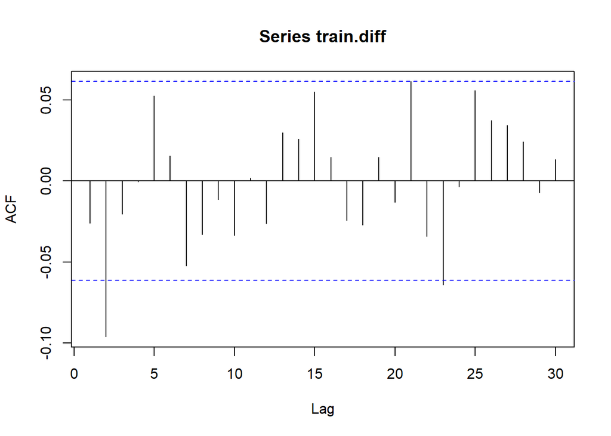

```r
acf(train.diff)
```

Berdasarkan plot tersebut, terlihat bahwa plot ACF cenderung cuts off pada lag ke-2, sehingga jika plot PACF dianggap tails off, maka model tentatifnya adalah ARIMA(0,1,2).

## 7.2 Plot PACF

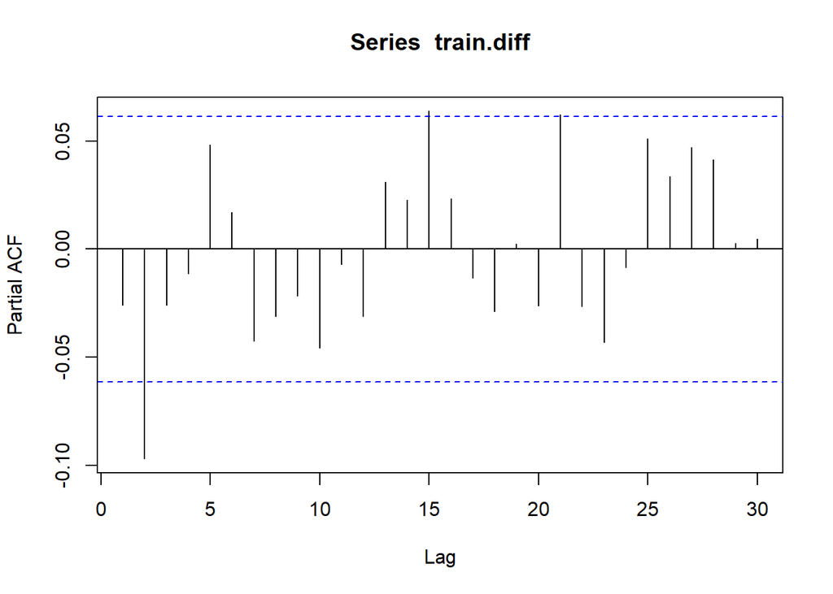

```r
pacf(train.diff)
```

## 7.3 Plot EACF

```r
eacf(train.diff)
```

```
AR/MA
  0 1 2 3 4 5 6 7 8 9 10 11 12 13
0 o x o o o o o o o o o  o  o  o
1 x x o o o o o o o o o  o  o  o
2 x o o o o o o o o o o  o  o  o
3 x o x o o o o o o o o  o  o  o
4 x x x o o o o o o o o  o  o  o
5 x x x o x o o o o o o  o  o  o
6 x x x x o x o o o o o  o  o  o
7 x o x x o x x o o o o  o  o  o
```

Berdasarkan tabel EACF, terlihat pola o yang mulai membentuk pola segitiga pada kolom MA ke-2. Dengan demikian, beberapa model tentatif yang dapat dipertimbangkan adalah ARIMA(0,1,2), ARIMA(1,1,2), dan ARIMA(2,1,2).

# 8 Pendugaan Parameter Model Tentatif

## 8.1 ARIMA (0,1,2)

```r
model1.da=Arima(train.diff, order=c(0,0,2),method="ML")
summary(model1.da)
```

```
Series: train.diff
ARIMA(0,0,2) with non-zero mean

Coefficients:
          ma1      ma2  mean
      -0.0320  -0.0975     0
s.e.   0.0311   0.0310     0

sigma^2 = 6.602e-07:  log likelihood = 5817.55
AIC=-11627.1   AICc=-11627.06   BIC=-11607.39

Training set error measures:
                        ME         RMSE         MAE MPE MAPE      MASE
Training set -8.920848e-08 0.0008113235 0.000585375 NaN  Inf 0.6796082
                    ACF1
Training set 0.001180411
```

```r
lmtest::coeftest(model1.da)
```

```
z test of coefficients:

             Estimate  Std. Error z value Pr(>|z|)
ma1       -3.1958e-02  3.1144e-02 -1.0261 0.304834
ma2       -9.7453e-02  3.0986e-02 -3.1450 0.001661 **
intercept  3.4744e-05  3.8319e-05  0.9067 0.364565
---
Signif. codes:  0 '***' 0.001 '**' 0.01 '*' 0.05 '.' 0.1 ' ' 1
```

## 8.2 ARIMA (1,1,2)

```r
model2.da=Arima(train.diff, order=c(1,0,2),method="ML")
summary(model2.da)
```

```
Series: train.diff
ARIMA(1,0,2) with non-zero mean

Coefficients:
         ar1      ma1      ma2  mean
      0.1007  -0.1315  -0.0934     0
s.e.  0.2864   0.2850   0.0340     0

sigma^2 = 6.608e-07:  log likelihood = 5817.61
AIC=-11625.22   AICc=-11625.16   BIC=-11600.58

Training set error measures:
                        ME         RMSE          MAE MPE MAPE     MASE
Training set -1.480223e-07 0.0008112759 0.0005855634 NaN  Inf 0.679827
                     ACF1
Training set 0.0001110126
```

```r
lmtest::coeftest(model2.da)
```

```
z test of coefficients:

             Estimate  Std. Error z value Pr(>|z|)
ar1        1.0067e-01  2.8642e-01  0.3515 0.725218
ma1       -1.3149e-01  2.8499e-01 -0.4614 0.644526
ma2       -9.3390e-02  3.3979e-02 -2.7484 0.005988 **
intercept  3.4787e-05  3.8191e-05  0.9108 0.362376
---
Signif. codes:  0 '***' 0.001 '**' 0.01 '*' 0.05 '.' 0.1 ' ' 1
```

## 8.3 ARIMA (2,1,2)

```r
model3.da=Arima(train.diff, order=c(2,0,2),method="ML")
summary(model3.da)
```

```
Series: train.diff
ARIMA(2,0,2) with non-zero mean

Coefficients:
         ar1      ar2      ma1     ma2  mean
      0.6045  -0.5714  -0.6378  0.5036     0
s.e.  0.2100   0.1867   0.2231  0.1937     0

sigma^2 = 6.598e-07:  log likelihood = 5818.81
AIC=-11625.62   AICc=-11625.54   BIC=-11596.05

Training set error measures:
                        ME         RMSE          MAE MPE MAPE      MASE
Training set -1.683003e-07 0.0008103174 0.0005864433 NaN  Inf 0.6808485
                     ACF1
Training set 0.0006875708
```

```r
lmtest::coeftest(model3.da)
```

```
z test of coefficients:

             Estimate  Std. Error z value Pr(>|z|)
ar1        6.0448e-01  2.0998e-01  2.8787 0.003993 **
ar2       -5.7143e-01  1.8672e-01 -3.0604 0.002210 **
ma1       -6.3781e-01  2.2313e-01 -2.8585 0.004256 **
ma2        5.0365e-01  1.9366e-01  2.6007 0.009304 **
intercept  3.4841e-05  3.8668e-05  0.9010 0.367568
---
Signif. codes:  0 '***' 0.001 '**' 0.01 '*' 0.05 '.' 0.1 ' ' 1
```

# 9 Ringkasan AIC

```r
model_tentatif <- data.frame(
  Model = c("ARIMA(0,1,2)","ARIMA(1,1,2)","ARIMA(2,1,2)"),
  AIC   = c(AIC(model1.da),AIC(model2.da), AIC(model3.da)),
  BIC   = c(BIC(model1.da),BIC(model2.da), BIC(model3.da))
)

model_tentatif
```

```
         Model       AIC       BIC
1 ARIMA(0,1,2) -11627.10 -11607.39
2 ARIMA(1,1,2) -11625.22 -11600.58
3 ARIMA(2,1,2) -11625.62 -11596.05
```

Berdasarkan hasil perbandingan nilai Akaike Information Criterion (AIC) dan Bayesian Information Criterion (BIC), midel ARIMA (0,1,2) adalah model terbaik.

# 10 Analaisis Sisaan

Model terbaik hasil identifikasi kemudian dicek asumsi sisaannya. Sisaan model ARIMA harus memenuhi asumsi normalitas, kebebasan sisaan, dan kehomogenan ragam. Diagnostik model dilakukan secara eksplorasi dan uji formal.

## 10.1 Eksplorasi Sisaan

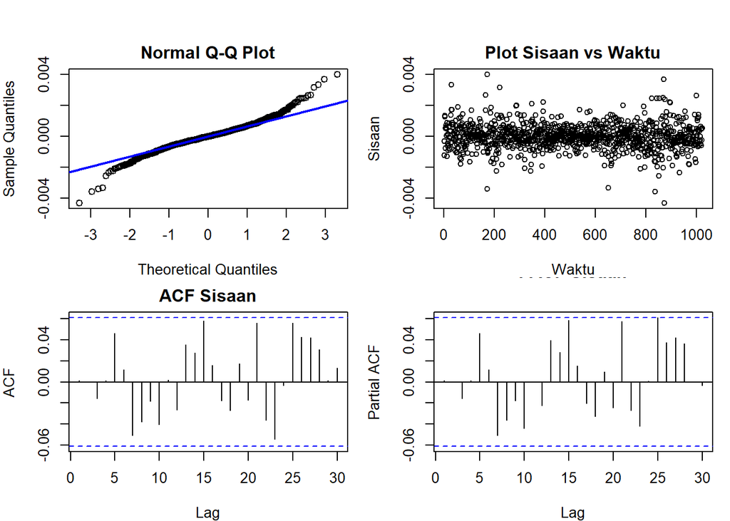

```r
sisaan.da <- model1.da$residuals

par(mfrow = c(2,2),
    mar = c(4,4,2,1),
    oma = c(0,0,2,0))

# Q-Q Plot
qqnorm(sisaan.da, main = "Normal Q-Q Plot")
qqline(sisaan.da, col = "blue", lwd = 2)

# Plot Sisaan vs Waktu
plot(sisaan.da, type = "p",
     main = "Plot Sisaan vs Waktu",
     xlab = "Waktu", ylab = "Sisaan")

# ACF
acf(sisaan.da, main = "ACF Sisaan")

# PACF
pacf(sisaan.da, main = "PACF Sisaan")
```

Berdasarkan plot kuantil-kuantil normal, secara eksploratif terlihat bahwa sisaan tidak sepenuhnya menyebar normal karena titik-titik cenderung menyimpang dari garis 45°, selain itu lebar pita sebaran sisaan tampak tidak seragam yang mengindikasikan adanya heterogenitas ragam, sementara plot ACF dan PACF sisaan dari model ARIMA(0,1,2) tidak menunjukkan adanya signifikansi.

## 10.2 Uji Formal

### 10.2.1 Normalitas

$$\begin{aligned}
H_0 &: \text{Sisaan model ARIMA(0,1,2) berdistribusi normal} \\
H_1 &: \text{Sisaan model ARIMA(0,1,2) tidak berdistribusi normal}
\end{aligned}$$

```r
#1) Sisaan Menyebar Normal
ks.test(sisaan.da,"pnorm")
```

```
    Asymptotic one-sample Kolmogorov-Smirnov test

data:  sisaan.da
D = 0.4984, p-value < 2.2e-16
alternative hypothesis: two-sided
```

Berdasarkan hasil uji Kolmogorov-Smirnov, diperoleh nilai statistik uji sebesar 0.4984 dengan $p-value < 2.2 × 10^{-16}$. Karena nilai p-value lebih kecil dari taraf signifikansi 5%, maka tOLAK $H_0$ Dengan demikian, terdapat bukti statistik yang cukup untuk menyatakan bahwa sisaan model ARIMA(0,1,2) tidak berdistribusi normal, sehingga asumsi normalitas sisaan belum terpenuhi.

### 10.2.2 Autokorelasi

$$\begin{aligned}
H_0 &: \text{Tidak terdapat autokorelasi pada sisaan model ARIMA(0,1,2)} \\
H_1 &: \text{Terdapat autokorelasi pada sisaan model ARIMA(0,1,2)}
\end{aligned}$$

```r
#2) Sisaan saling bebas/tidak ada autokorelasi
Box.test(sisaan.da, type = "Ljung")
```

```
    Box-Ljung test

data:  sisaan.da
X-squared = 0.0014268, df = 1, p-value = 0.9699
```

Berdasarkan hasil uji Box-Ljung, diperoleh p-value sebesar 0.9699. Karena nilai $p-value > 0,05$, maka keputusan pengujian adalah Tak Tolak $H_0$ Dengan demikian, tidak terdapat bukti yang cukup untuk menyatakan adanya autokorelasi pada sisaan model ARIMA(0,1,2). Hal ini menunjukkan bahwa sisaan model telah memenuhi asumsi independensi berdasarkan pengujian Box-Ljung.

### 10.2.3 Homogenitas

$$\begin{aligned}
H_0 &: \text{Ragam sisaan model ARIMA(0,1,2) homogen} \\
H_1 &: \text{Ragam sisaan model ARIMA(0,1,2) tidak homogen}
\end{aligned}$$

```r
#3) Sisaan homogen
Box.test((sisaan.da)^2, type = "Ljung")
```

```
    Box-Ljung test

data:  (sisaan.da)^2
X-squared = 23.307, df = 1, p-value = 1.381e-06
```

### 10.2.4 Nilai tengah sisaan sama dengan nol

$$\begin{aligned}
H_0 &: \mu_{\varepsilon} = 0 \\
H_1 &: \mu_{\varepsilon} \neq 0
\end{aligned}$$

```r
#4) Nilai tengah sisaan sama dengan nol
t.test(sisaan.da, mu = 0, conf.level = 0.95)
```

```
    One Sample t-test

data:  sisaan.da
t = -0.0035117, df = 1020, p-value = 0.9972
alternative hypothesis: true mean is not equal to 0
95 percent confidence interval:
 -4.993835e-05  4.975993e-05
sample estimates:
    mean of x
-8.920848e-08
```

Berdasarkan hasil uji One Sample t-test pada sisaan model ARIMA(0,1,2), diperoleh nilai statistik uji sebesar -0.0035117 dengan derajat bebas 1020 dan $p-value = 0.9972 > 0,05$, maka keputusan pengujian adalah Tak Tolak $H_0$. Oleh karena itu, tidak terdapat bukti statistik yang cukup untuk menyatakan bahwa nilai tengah sisaan berbeda dari nol. Hal ini menunjukkan bahwa nilai tengah sisaan model ARIMA(0,1,2) secara statistik tidak berbeda signifikan dari nol, sehingga asumsi nilai tengah sisaan sama dengan nol terpenuhi.

# 11 Overfitting

```r
model2.da=Arima(train.diff, order=c(0,0,3),method="ML")
summary(model2.da)
```

```
Series: train.diff
ARIMA(0,0,3) with non-zero mean

Coefficients:
          ma1      ma2      ma3  mean
      -0.0307  -0.0962  -0.0117     0
s.e.   0.0313   0.0312   0.0315     0

sigma^2 = 6.607e-07:  log likelihood = 5817.62
AIC=-11625.24   AICc=-11625.18   BIC=-11600.6

Training set error measures:
                        ME         RMSE          MAE MPE MAPE      MASE
Training set -9.247346e-08 0.0008112684 0.0005856301 NaN  Inf 0.6799044
                      ACF1
Training set -2.308786e-05
```

```r
lmtest::coeftest(model2.da)
```

```
z test of coefficients:

             Estimate  Std. Error z value Pr(>|z|)
ma1       -3.0717e-02  3.1308e-02 -0.9811 0.326533
ma2       -9.6235e-02  3.1230e-02 -3.0815 0.002059 **
ma3       -1.1720e-02  3.1518e-02 -0.3718 0.710006
intercept  3.4739e-05  3.8183e-05  0.9098 0.362935
---
Signif. codes:  0 '***' 0.001 '**' 0.01 '*' 0.05 '.' 0.1 ' ' 1
```

```r
AIC(model2.da)
```

```
[1] -11625.24
```

# 12 Model Terbaik

## 12.1 ARIMA(0,1,2)

```r
model1.da <- Arima(train.diff,
                   order = c(0,0,2),
                   method = "ML")

summary(model1.da)
```

```
Series: train.diff
ARIMA(0,0,2) with non-zero mean

Coefficients:
          ma1      ma2  mean
      -0.0320  -0.0975     0
s.e.   0.0311   0.0310     0

sigma^2 = 6.602e-07:  log likelihood = 5817.55
AIC=-11627.1   AICc=-11627.06   BIC=-11607.39

Training set error measures:
                        ME         RMSE         MAE MPE MAPE      MASE
Training set -8.920848e-08 0.0008113235 0.000585375 NaN  Inf 0.6796082
                    ACF1
Training set 0.001180411
```

```r
lmtest::coeftest(model1.da)
```

```
z test of coefficients:

             Estimate  Std. Error z value Pr(>|z|)
ma1       -3.1958e-02  3.1144e-02 -1.0261 0.304834
ma2       -9.7453e-02  3.0986e-02 -3.1450 0.001661 **
intercept  3.4744e-05  3.8319e-05  0.9067 0.364565
---
Signif. codes:  0 '***' 0.001 '**' 0.01 '*' 0.05 '.' 0.1 ' ' 1
```

# 13 Forecasting

```r
ramalan.da <- forecast::forecast(model1.da, h = length(test.ts))
```

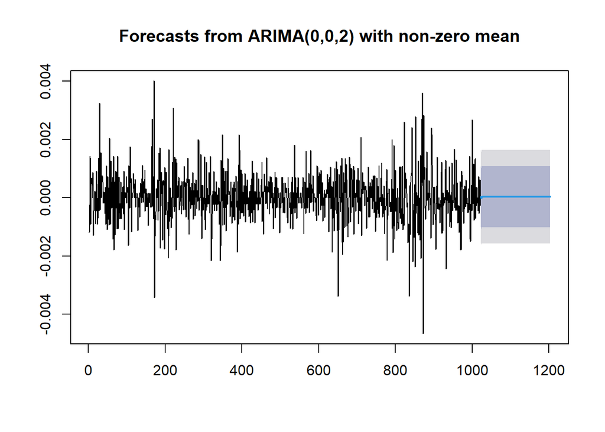

```r
data.ramalan.da <- ramalan.da$mean
plot(ramalan.da)
```

```r
# Inverse differencing
# 1) Inverse differencing (pada skala Box-Cox)
bc.fc <- diffinv(ramalan.da$mean, xi = tail(train.bc, 1))[-1]

# 2) Inverse Box-Cox (kembali ke skala harga asli)
hasil <- InvBoxCox(bc.fc, lambda = lambda)

# Bandingkan aktual vs forecast
perbandingan.da <- cbind(
  Aktual   = test.ts,
  Forecast = hasil
)

print(head(perbandingan.da, 10))
```

```
Time Series:
Start = 1
End = 10
Frequency = 1
     Aktual Forecast
 1 4447.946 4371.134
 2 4456.951 4369.322
 3 4592.009 4372.932
 4 4524.480 4376.546
 5 4524.480 4380.163
 6 4375.915 4383.785
 7 4348.903 4387.412
 8 4375.915 4391.042
 9 4366.911 4394.676
10 4393.923 4398.315
```

```r
# Hitung akurasi
akurasi_test <- accuracy(hasil, test.ts)
akurasi_test
```

```
                ME     RMSE      MAE       MPE     MAPE      ACF1 Theil's U
Test set -381.2651 551.4597 441.4254 -9.272495 10.55978 0.9667093  6.377403
```

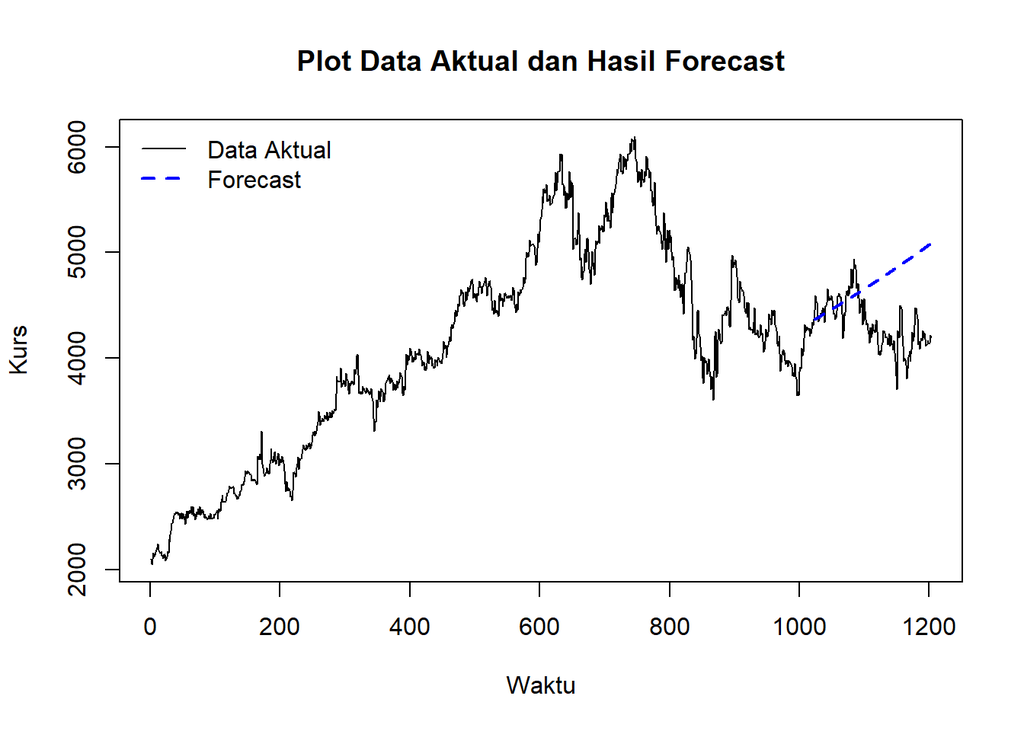

```r
# Forecast
ts.plot(data.ts, col = "black", lty = 1,
        xlab = "Waktu", ylab = "Kurs",
        main = "Plot Data Aktual dan Hasil Forecast")

# Garis forecast
lines(1023:1203, hasil, col = "blue", lty = 2, lwd = 2)

# Legend
legend("topleft",
       legend = c("Data Aktual", "Forecast"),
       col = c("black", "blue"),
       lty = c(1, 2), lwd = c(1, 2),
       bty = "n")
```

Berdasarkan hasil evaluasi menggunakan data testing, model ARIMA(0,1,2) menghasilkan nilai RMSE sebesar 551.4597, MAE sebesar 441.4254, dan MAPE sebesar 10.55978. Nilai MAPE menunjukkan bahwa rata-rata kesalahan prediksi secara relatif terhadap nilai aktual adalah sekitar 10,56%. Sementara itu, nilai ME sebesar -381.2651 dan MPE sebesar -9,27% menunjukkan adanya kecenderungan prediksi yang lebih tinggi dibandingkan nilai aktual.